# 9_3_Assignment_Residuals_Analysis

```r
library(fpp3)
library(patchwork) # to easily locate graphs next to each other
```

# Exercise 1

1. Apply a naïve method to the Australian Exports series from the dataset `global_economy`

```r
aus_exports <- filter(global_economy, Country == "Australia")

# Define and estimate a model
fit <- aus_exports %>% model(Nv = NAIVE(Exports))

fit
```

```
## # A mable: 1 x 2
## # Key:     Country [1]
##   Country        Nv
##   <fct>     <model>
## 1 Australia <NAIVE>
```

**QUESTION: what does the number of rows in this mable represent?**

**QUESTION: what does the number of columns in this mable represent?**

2. Extract the fitted values and the residuals

```r
model_vals <- fit %>% augment()

model_vals
```

```
## # A tsibble: 58 x 7 [1Y]
## # Key:       Country, .model [1]
##    Country   .model  Year Exports .fitted  .resid  .innov
##    <fct>     <chr>  <dbl>   <dbl>   <dbl>   <dbl>   <dbl>
##  1 Australia Nv      1960    13.0    NA   NA      NA
##  2 Australia Nv      1961    12.4    13.0 -0.591  -0.591
##  3 Australia Nv      1962    13.9    12.4  1.54    1.54
##  4 Australia Nv      1963    13.0    13.9 -0.937  -0.937
##  5 Australia Nv      1964    14.9    13.0  1.93    1.93
##  6 Australia Nv      1965    13.2    14.9 -1.72   -1.72
##  7 Australia Nv      1966    12.9    13.2 -0.288  -0.288
##  8 Australia Nv      1967    12.9    12.9 -0.0487 -0.0487
##  9 Australia Nv      1968    12.3    12.9 -0.586  -0.586
## 10 Australia Nv      1969    12.0    12.3 -0.343  -0.343
## # ... with 48 more rows
```

**QUESTION: what object is the output of `augment()`?**

- **QUESTION: how many rows does its output have?**

**QUESTION: what object is the input of `augment()`**

3. Depict the fitted values

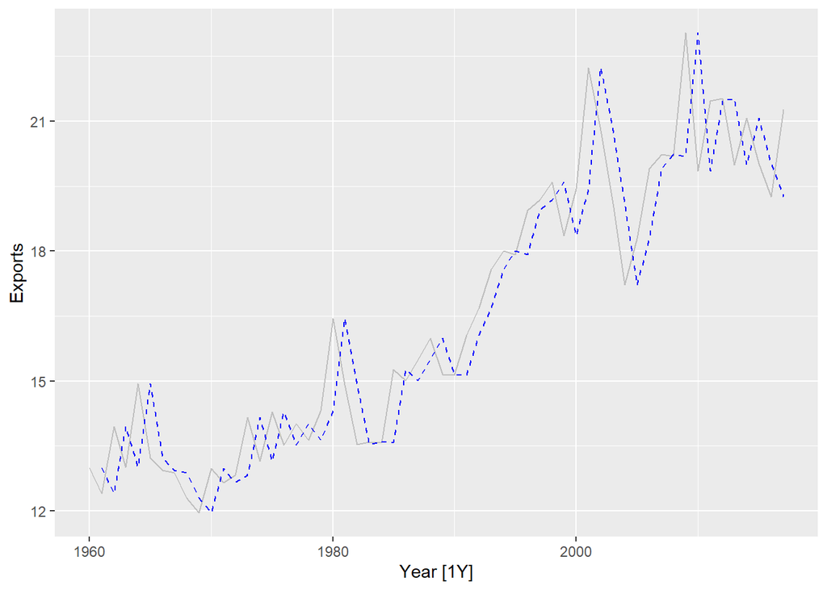

```r
model_vals %>%
  filter(.model == "Nv") %>%
  autoplot(Exports, colour = "gray") +
  geom_line(aes(y=.fitted), colour = "blue", linetype = "dashed")
```

**QUESTION: what are the fitted values and what are the time series values?**

- Fitted values are the approximation of the values generated by the model based on the available data.
4. Perform the analysis of the residuals. Be as clear as succint and possible, splitting your analysis in the 4 following points:

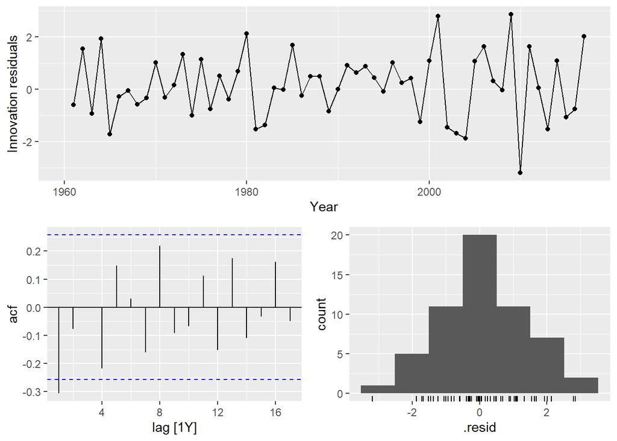

```r
fit %>%
  select(Nv) %>%
  gg_tsresiduals()
```

```r
# Compute the mean of the residuals
model_vals %>% as_tibble() %>%
  filter(.model == "Nv") %>%
  summarise(mean = mean(.innov, na.rm = TRUE))
```

```
## # A tibble: 1 x 1
##    mean
##   <dbl>
## 1 0.145
```

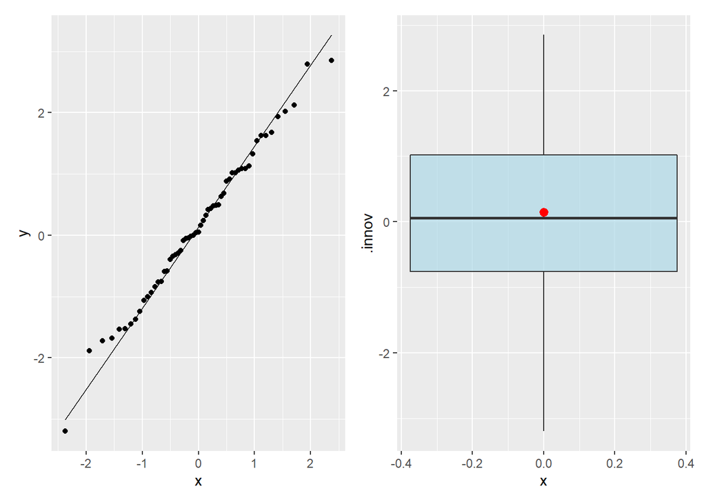

```r
# In this case there is only one model, so this filtering is not really necessary.
nv_vals <- filter(model_vals, .model=="Nv")

# Generate qq_plot
p1 <- ggplot(nv_vals, aes(sample = .innov)) +
        stat_qq() +
        stat_qq_line()

# # Generate box-plot
p2 <- ggplot(data = nv_vals, aes(y = .innov)) +
      geom_boxplot(fill="light blue", alpha = 0.7) +
      stat_summary(aes(x=0), fun="mean", colour= "red") # Include the mean

# Place one graph next to the other (library patchwork)
p1 + p2
```

- Autocorrelation of the residuals

Except for the first lag, the rest of the autocorrelation coefficients are within the boundaries of negligible autocorrelation. The series might therefore still be white noise (5% of the ACF of white noise are expected to randomly exceed this threshold due to Type I error).

TO gather further evidence, a Box-Pierce or Ljung test could be carried out (not requested in this session).

- 0 mean

The mean of the residuals differs from 0, which means that forecasts generated with this model will be somewhat biased. + More observations appear to be above 0, indicating that the model does not capture the trend.

- Homoskedasticity

The residuals seem fairly homoskedastic, except maybe for some local heteroskedasticity aroudn 2010. The effect is not si marked to be considered relevant

- Normality

The histogram (symmetric and with balanced tails), QQ-plot (quantiles follow the normal cummulative distribution) and Box-Plot (mean close to median and symmetry) all seem to indicate that the normality assumption is fair.

**QUESTION What if we want to fit the model to more than one country of the dataset `global_economy`?**

```r
aus_exports <- filter(global_economy, Country %in% c("Australia", "Spain", "Germany"))

# Define and estimate a model
fit <- aus_exports %>% model(
                                Nv = NAIVE(Exports),
                                Mean = MEAN(Exports)
                             )

fit
```

```
## # A mable: 3 x 3
## # Key:     Country [3]
##   Country        Nv    Mean
##   <fct>     <model> <model>
## 1 Australia <NAIVE>  <MEAN>
## 2 Germany   <NAIVE>  <MEAN>
## 3 Spain     <NAIVE>  <MEAN>
```

# Exercise 2

Using the Facebook stock price (dataset `gafa_stock`):

```r
fb_stock <- gafa_stock %>%
  filter(Symbol == "FB")

head(fb_stock)
```

```
## # A tsibble: 6 x 8 [!]
## # Key:       Symbol [1]
##   Symbol Date        Open  High   Low Close Adj_Close   Volume
##   <chr>  <date>     <dbl> <dbl> <dbl> <dbl>     <dbl>    <dbl>
## 1 FB     2014-01-02  54.8  55.2  54.2  54.7      54.7 43195500
## 2 FB     2014-01-03  55.0  55.7  54.5  54.6      54.6 38246200
## 3 FB     2014-01-06  54.4  57.3  54.0  57.2      57.2 68852600
## 4 FB     2014-01-07  57.7  58.5  57.2  57.9      57.9 77207400
## 5 FB     2014-01-08  57.6  58.4  57.2  58.2      58.2 56682400
## 6 FB     2014-01-09  58.7  59.0  56.7  57.2      57.2 92253300
```

1. Select the values in 2015 and apply a naïve method to the data

```r
# Filter year 2015 and create regularly spaced time index based on trading day
fb_2015 <- fb_stock %>%
            filter(year(Date) == 2015) %>%
            mutate(day = row_number()) %>%
            update_tsibble(index = day, regular = TRUE)

# Fit the model
fit <- fb_2015 %>%
  model(Nv = NAIVE(Close))

fit
```

```
## # A mable: 1 x 2
## # Key:     Symbol [1]
##   Symbol      Nv
##   <chr>  <model>
## 1 FB     <NAIVE>
```

2. Extract the fitted values and the residuals

```r
model_vals <- fit %>% augment()

head(model_vals)
```

```
## # A tsibble: 6 x 7 [1]
## # Key:       Symbol, .model [1]
##   Symbol .model   day Close .fitted .resid .innov
##   <chr>  <chr>  <int> <dbl>   <dbl>  <dbl>  <dbl>
## 1 FB     Nv         1  78.4    NA   NA     NA
## 2 FB     Nv         2  77.2    78.4 -1.26  -1.26
## 3 FB     Nv         3  76.2    77.2 -1.04  -1.04
## 4 FB     Nv         4  76.2    76.2  0      0
## 5 FB     Nv         5  78.2    76.2  2.03   2.03
## 6 FB     Nv         6  77.7    78.2 -0.440 -0.440
```

3. Depict the fitted values

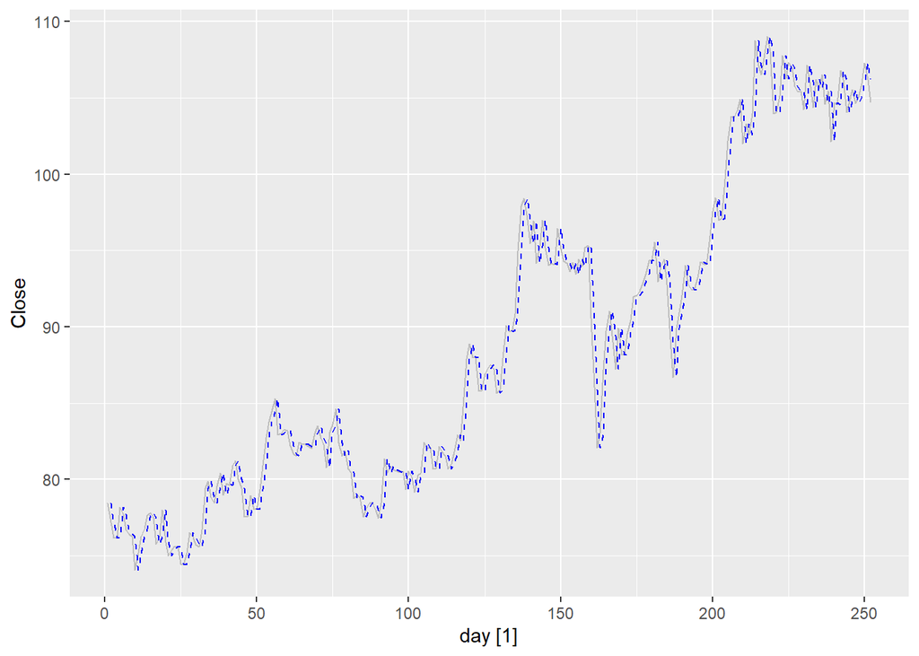

```r
# Plot fitted values for the NAIVE model:
model_vals %>%
  filter(.model == "Nv") %>%
  autoplot(Close, colour = "gray") +
  geom_line(aes(y=.fitted), colour = "blue", linetype = "dashed")
```

4. Perform the analysis of the residuals. Be as clear and succint as possible, splitting your analysis in the 4 following points:

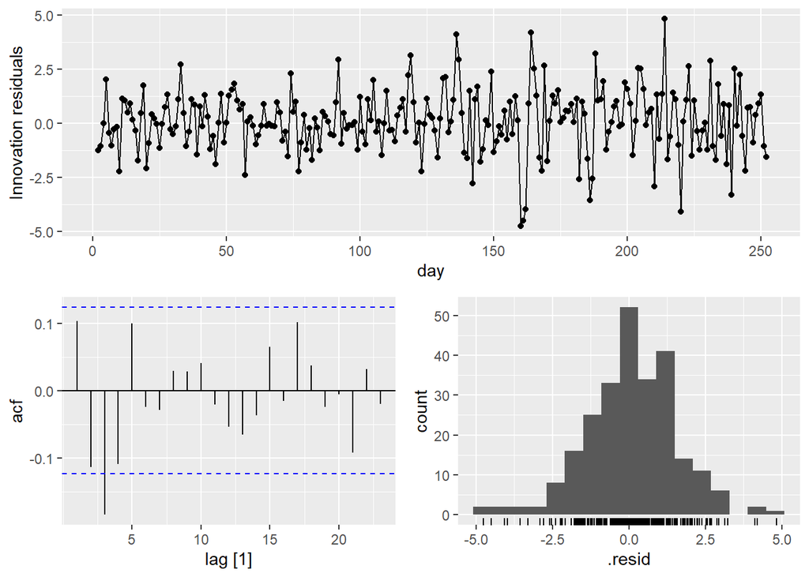

```r
fit %>%
  select(Nv) %>% # Selects the Mean model
  gg_tsresiduals()
```

```r
# Compute the mean of the residuals
model_vals %>% as_tibble() %>%
  filter(.model == "Nv") %>%
  summarise(mean = mean(.innov, na.rm = TRUE))
```

```
## # A tibble: 1 x 1
##    mean
##   <dbl>
## 1 0.104
```

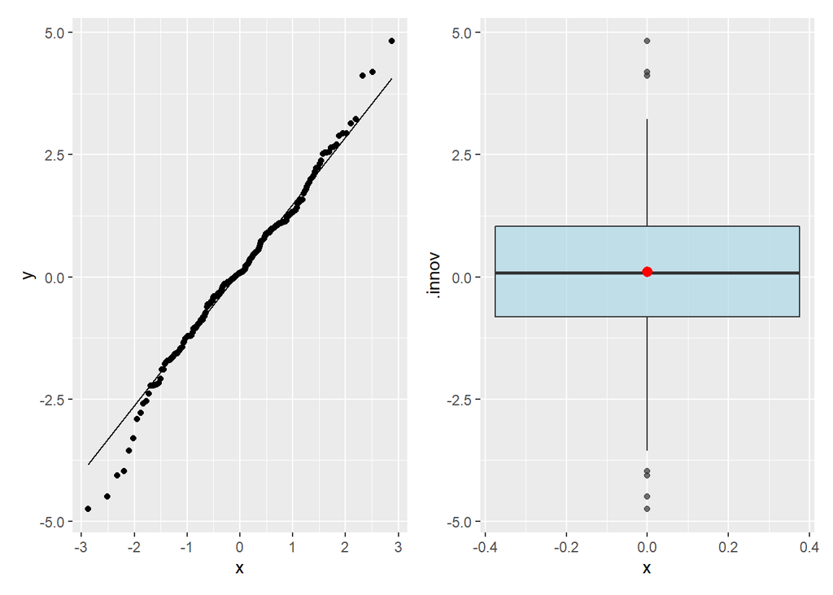

```r
# In this case there is only one model, so this filtering is not really necessary.
nv_vals <- filter(model_vals, .model=="Nv")

# Generate qq_plot
p1 <- ggplot(nv_vals, aes(sample = .innov)) +
        stat_qq() +
        stat_qq_line()

# # Generate box-plot
p2 <- ggplot(data = nv_vals, aes(y = .innov)) +
      geom_boxplot(fill="light blue", alpha = 0.7) +
      stat_summary(aes(x=0), fun="mean", colour= "red") # Include the mean

# Place one graph next to the other (library patchwork)
p1 + p2
```

- Autocorrelation of the residuals

- 0 mean

The mean of the residuals are slightly above 0, which would result in biased forecasts.

- Homoskedasticity

Heteroskedasticity seems only local